# Data Science Salaries Analysis Report

Piotr Sikora

# Introduction

This report examines compensation and employment trends in the data science field using a comprehensive salary dataset. Understanding salary structures, geographic variations, and the relationship between experience and compensation is crucial for both employers setting competitive offers and professionals navigating career decisions.

**Objective:** To analyze salary distributions across experience levels, company sizes, and geographic regions; examine employment patterns including remote work arrangements; and identify key factors influencing compensation in data science roles.

**Dataset Overview:** The dataset contains 3755 employment records spanning multiple years with information on work year, experience level, employment type, job title, salary (in multiple currencies and standardized USD), employee residence, remote work ratio, company location, and company size.

# Salary Distributions

## Overall Salary Distribution

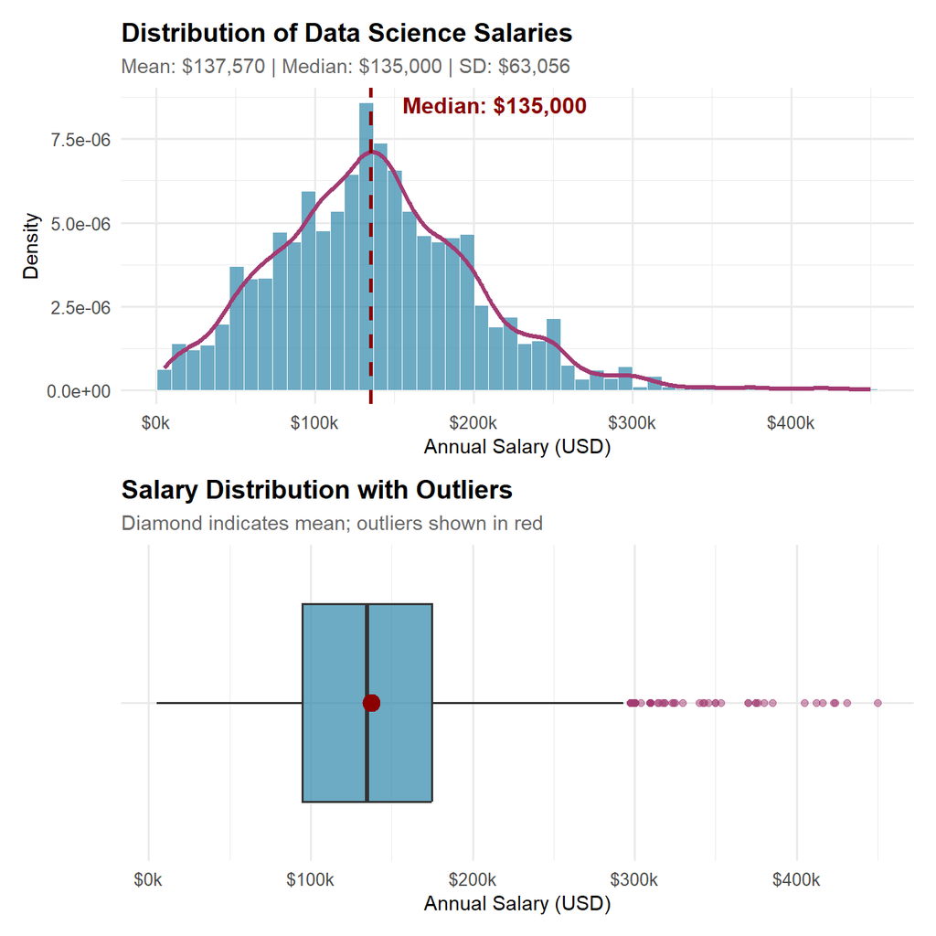

The salary distribution shows right-skewed characteristics with a median of $135,000 and mean of $137,570. The positive skew indicates a concentration of positions in the lower-to-middle salary ranges with a long tail of high-compensation roles, typical of data science markets with significant variation in role seniority and specialization.

## Salary Distribution by Experience Level

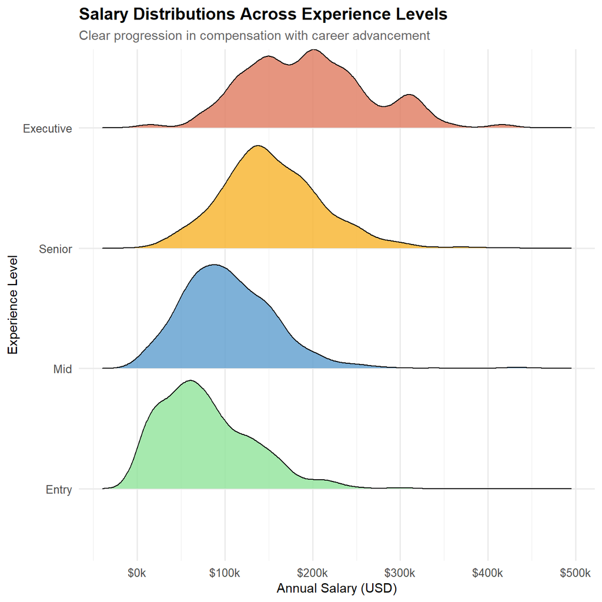

Ridge plots reveal distinct salary distributions for each experience tier. Entry-level positions cluster around 60-80k dollars, mid-level around 80-120k dollars, senior positions show broader distribution centered near 140-160k dollars, and executive roles display the widest range with peaks above 180k dollars. The increasing spread at higher levels reflects greater variation in responsibilities and organizational contexts.

## Comparative Analysis by Experience and Company Size

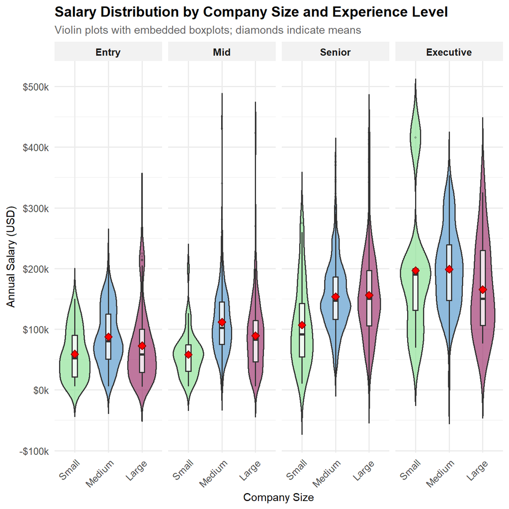

# Employment Patterns

## Distribution of Employment Types

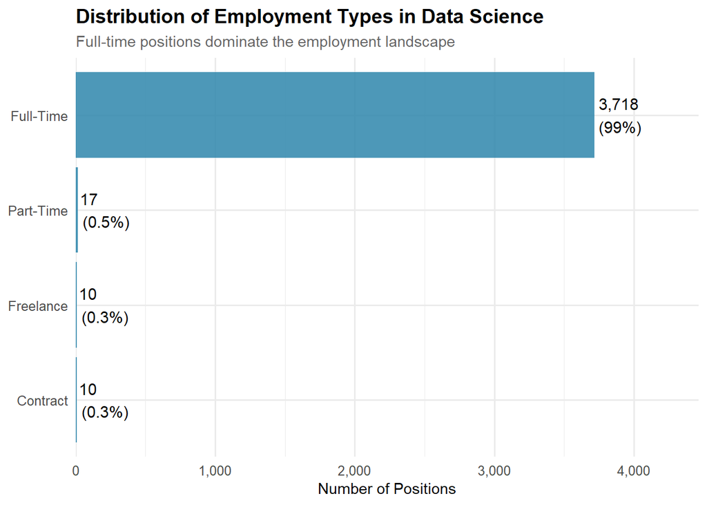

Full-time employment overwhelmingly dominates the data science field, accounting for over 99% of positions in the dataset. Contract, freelance, and part-time arrangements remain rare, suggesting that organizations prefer traditional employment relationships for data science roles, likely due to the need for sustained engagement with complex projects and organizational knowledge.

## Remote Work Arrangements

[figure not shown]

# Temporal and Geographic Trends

## Salary Trends Over Time

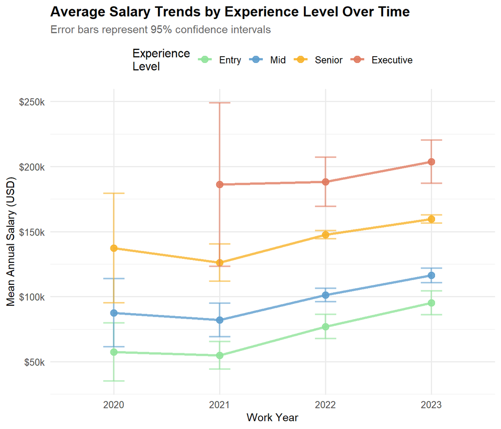

Temporal analysis reveals evolving compensation trends across the years covered in the dataset. The inclusion of error bars representing 95% confidence intervals indicates the statistical uncertainty around these estimates. All experience levels show year-to-year variation, with executive and senior roles maintaining higher absolute compensation. Variation of compensation across experience levels dialed down since 2022, likely due to the recent tech boom slowing down after COVID-19 pandemic ended.

## Top Job Titles by Volume

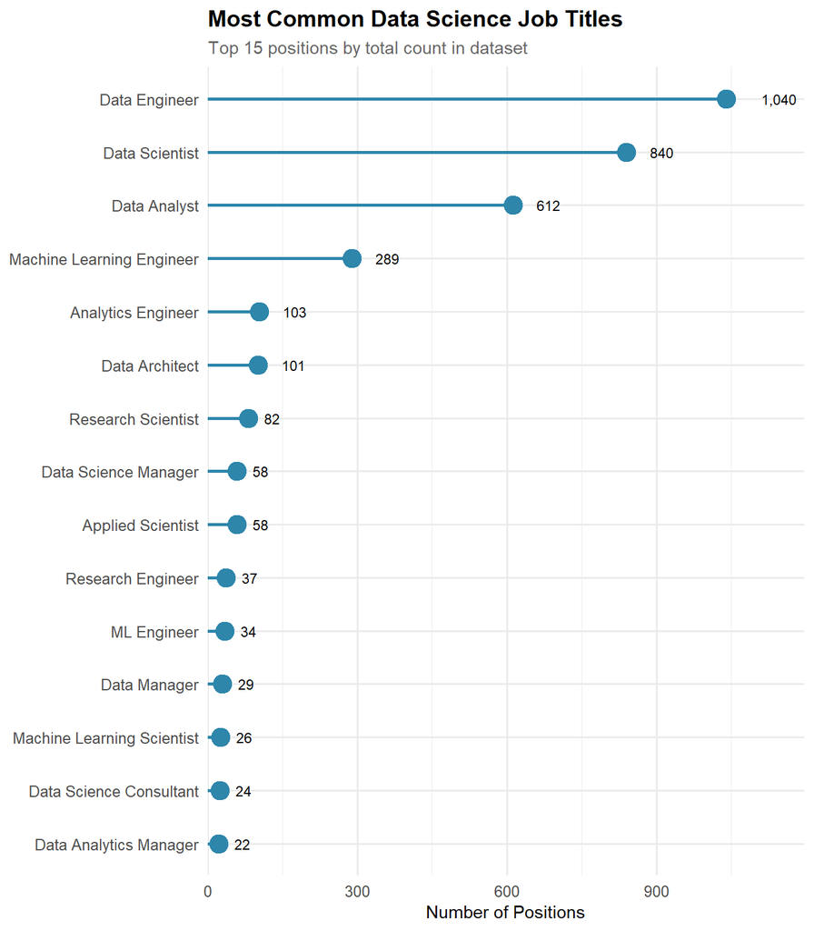

Job title analysis reveals the diversity of roles within data science. Data Scientist, Data Engineer, and Data Analyst comprise the most common positions, collectively representing the core of data science teams. More specialized roles like Machine Learning Engineer and Analytics Engineer also show substantial representation, reflecting the field’s maturation and specialization.

## Geographic Distribution of Salaries

[figure not shown]

Geographic analysis of compensation shows substantial variation across countries. US and Canada-based positions typically show higher median salaries and wider interquartile ranges, reflecting the mature tech market and high cost of living in major tech hubs. Other countries display more compressed salary ranges with lower medians, though some show competitive compensation at upper quartiles.

# Compensation Analysis

## Salary Distribution by Company Size

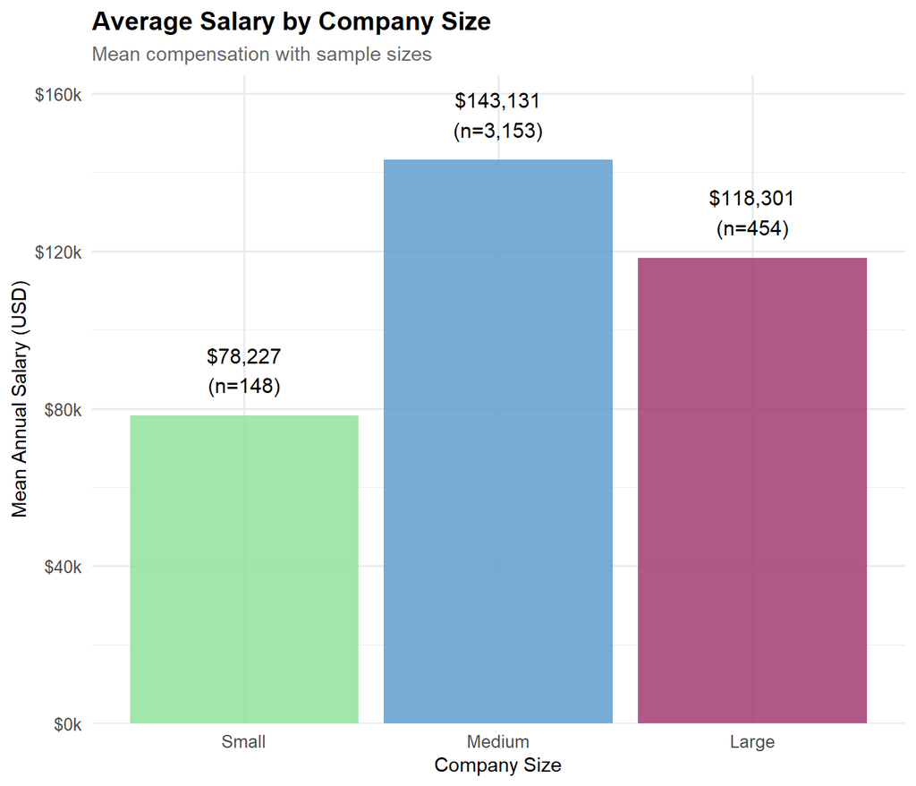

## Remote Work Impact on Compensation

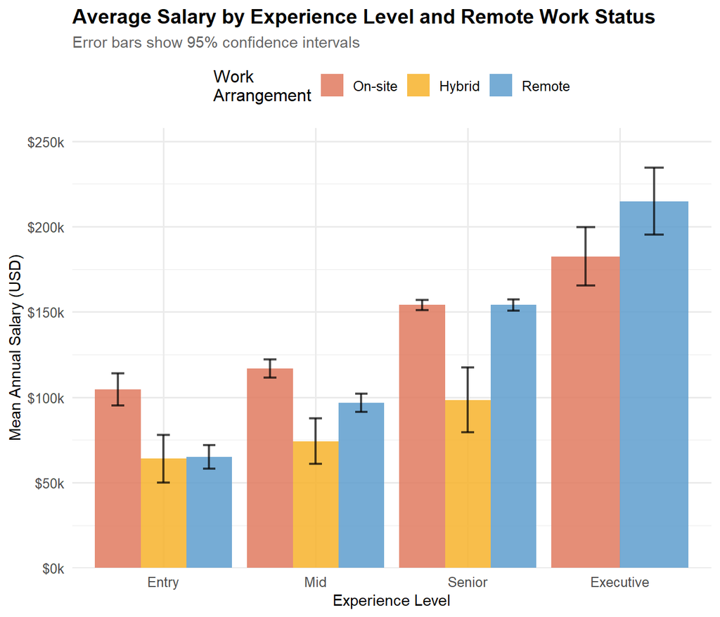

## Salary Categories by Experience

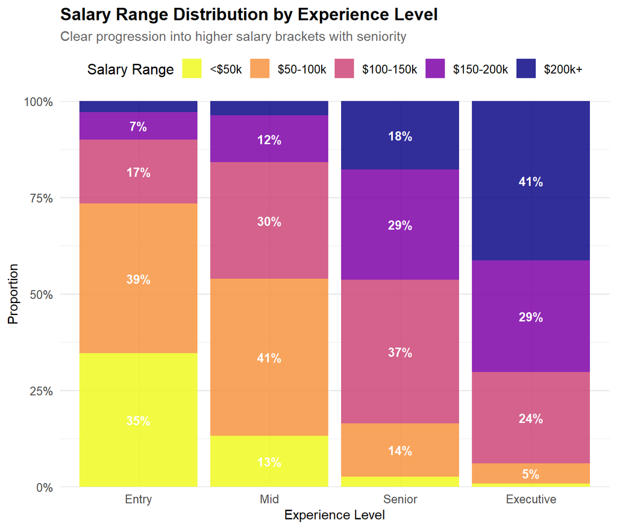

Salary category distributions demonstrate clear career progression patterns. Entry-level positions concentrate heavily in the <50k and 50-100k ranges, with some representation above 150k. Senior roles show more balanced distribution across middle categories, while executive positions predominantly occupy the 150k+ brackets, with significant representation above 200k. This progression validates expected career earnings trajectories.

# Summary and Conclusions

This comprehensive analysis of data science employment and compensation reveals several critical insights:

**Market Dynamics:**

- Substantial geographic variation in compensation, with US/CA positions commanding premium salaries
- Temporal trends show year-over-year variation with experience level differentiation maintained
- Job title diversity reflects field specialization, with Data Scientist, Engineer, and Analyst as core roles

**Key Relationships:**

- Experience level is the strongest determinant of compensation
- Remote work arrangements show neutral-to-positive compensation impact at senior and executive levels
- Medium-sized companies offer competitive compensation compared to large enterprises

**Professional Implications:**

For employers: Compensation must align with experience tiers to remain competitive. Remote work flexibility is increasingly expected at all levels without necessarily commanding premium pay.

The data science employment market shows maturation with clear career ladders, though substantial geographic and organizational variation persists. The field’s evolution toward remote work and specialization suggests continued dynamic adaptation in coming years.

**Methodological Notes:** Analysis includes 95% confidence intervals on temporal and grouped estimates to represent statistical uncertainty. Sample size filters applied to geographic analyses to ensure reliable estimates.